# Lab Solutions

Jyotishka Datta

February 1, 2019

## Problem 1

A ``truncated" distribution is a distribution where the support of the random variable is restricted to some interval $[a,b]$. If we know the pdf $f(x)$ and cdf $F(x)$ of the original random variable, then the pdf and cdf of the truncated random variable can be easily derived as:
$$f_{Tr}(x) = \begin{cases}
\frac{f(x)}{F(b) - F(a)} \; \forall a < x \le b \\
0 \; \text{otherwise}
\end{cases}$$
Consider the exponential random variable $X \sim \text{Exp}(\lambda)$, with pdf
$$f(x) = \lambda e^{-\lambda x}, \; x \ge 0, \lambda > 0$$

Answer the following:

1. How would you generate from an exponential truncated to the interval $[0,b]$ using accept-reject scheme? Try the R code for $\lambda = 2$, $b = 5$.
2. Can you use the inverse CDF transformation here?

## Solution

Part 1 is easy. All you have to do is sample from $Exp(\lambda)$ and discard all samples that fall outside the truncation boundary. Also, to generate from exponential we can use the inverse CDF method with
$$F^{-1}(u) = - \frac{1}{\lambda} \log(1-u)$$

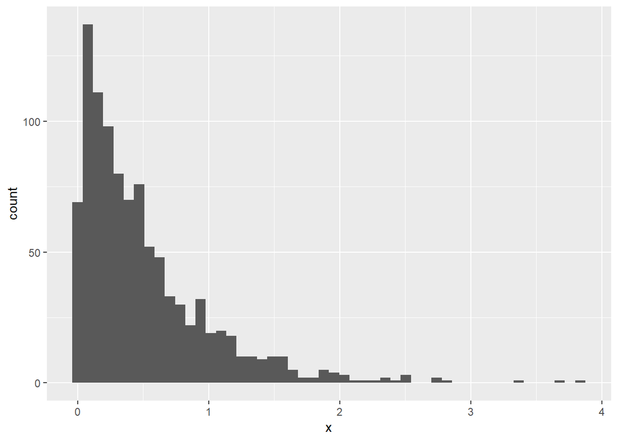

```r
set.seed(123)
n = 1000
u = runif(n)
lambda = 2
a = 0
b = 5

x = (-1/lambda)*log(1-u*(1-exp(-lambda*b)))
## Standard Exponential then truncate
x = -1/lambda*log(u) #u ~ U[0,1] implies 1-u ~ U[0,1]
x = x[x<=b]

## Plotting
library(ggplot2)
ggplot(data.frame(x))+geom_histogram(aes(x=x),bins = 50)
```

Part 2 involves a little math! The pdf of the truncated distribution is given above. We can then calculate the CDF of the truncated exponential:

First the area between $[a,b]$ would be
$$\int_{a}^{b} \lambda e^{-\lambda x} d x = F(b)-F(a) = e^{-\lambda a} - e^{-\lambda b}$$

The CDF for the truncated distribution can be written as:
$$F_{tr}(x) = \frac{F(x)-F(a)}{F(b)-F(a)}, a \le x \le b$$

Since $F(0) = 0$ for exponential, the inverse can be derived by solving the following equation for $x$
$$\text{Solve } u = \frac{F(x)-F(a)}{F(b)-F(a)} = \frac{1- \exp(-\lambda x)}{1- exp(-\lambda b)} \\
1 - exp(-\lambda x) = u (1 - exp(-\lambda b)) \\
x = (-1/\lambda)*\log(1-u (1 - exp(-\lambda b)))$$
The R code can be written as follows:

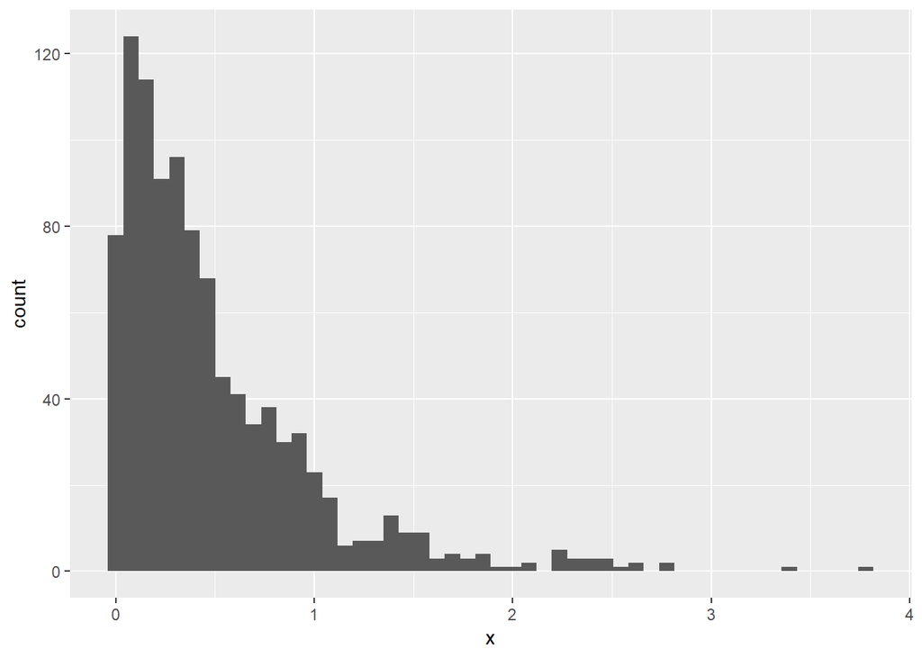

```r
n = 1000
lambda = 2
b = 5
u = runif(n)
x = (-1/lambda)*log(1-u*(1-exp(-lambda*b)))

## Plotting
library(ggplot2)
ggplot(data.frame(x))+geom_histogram(aes(x=x),bins = 50)
```

## Problem 2 (Bonus Problem)

**(Standard Normal Sampling without Box-Muller)**

The aim of this problem is to generate standard normal random variables by a different method. To do this, generate $U \sim \text{Unif}[0.1]$, and apply the following approximation to the inverse CDF for standard Normal:
$$\Phi^{-1}(\alpha) = t - \frac{a_0 + a_1 t}{1 + b_1 t + b_2 t^2},$$
where $t^2 = \log(\alpha^{-2})$ and
$$a_0 = 2.30753; a_1 = 0.27061; b_1 = 0.99229, b_2 = 0.04481.$$
Plot the histogram of the generated $X$ samples, and compare it with a standard $N(0,1)$ density curve. Do they look similar? Will you be able to use these samples for your experiments? Submit the plot and the R code.

## Solution

The following solution was submitted by Samrat Nath. This is a good example of well-documented coding.

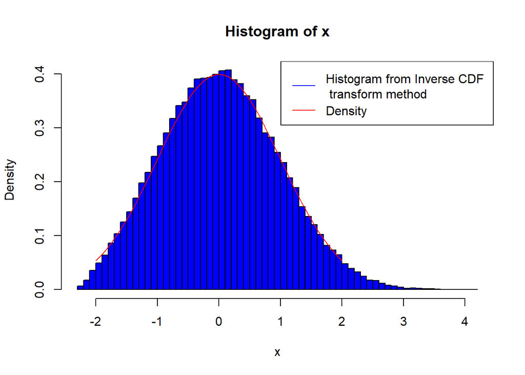

```r
# Inverse CDF transform method
Finv <- function(a){
  t=sqrt(log(1/(a*a)))
  a0 = 2.30753
  a1 = 0.27061
  b1 = 0.99229
  b2 = .04481
  x= t - ((a0+a1*t)/(1+b1*t+b2*t*t))
}

n=1e5
u= runif(n)
x=Finv(u)

y=seq(-2,2,0.05)
fy= (exp(-(y^2)/2))/(sqrt(2*pi))

hist(x,breaks = 50, freq=F, col= "blue")
lines(y, fy, col = "red")
legend("topright",c("Histogram from Inverse CDF \n transform method","Density"),
       col=c("blue","red"), lty = c(1,1))
```